# Metropolis Hasting

Muhammad Al Fatah

6/9/2021

**Catatan : Kodingan ini untuk memenuhi tugas simdat, kemungkinan banyak kesalahan. Mohon dimaklumi**  
# Metropolis Hasting

## Contoh Metropolis Hasting (1)

Misalkan fungsi:
$$\begin{align*}
f(y) = c & exp(-y^4)(1+|y|)^3 \\
& {-\infty}<y<\infty
\end{align*}$$
dengan $c$ adalah *normalizing constant*

Densitas proposal $q(x,y)=q(y|x)$ dan memutuskan apakah menerima atau tidak proposal ini dengan peluang $\alpha(x,t)$. Unutuk proposal ini, dipilih densitas yang mendekati $f(y)$ dan mudah disimulasikan. Di sini kita gunakan distribusi normal dengan rata-rata sama dengan nilai sebelumnya diterima value, $x$, dan varians 1. Peluang diterimanya adalah:

$$\begin{align*}
\alpha(x,y) & = min\{1,\frac{f(y)q(y,x)}{f(x)q(x,y)}\} \\
& = min\{1,\frac{c exp(-y^4)(1+|y|)^3(2\pi)^{-1/2}exp(-(y-x)^2/2)}{c exp(-x^4)(1+|x|)^3(2\pi)^{-1/2}exp(-(x-y)^2/2)}\} \\
& = min\{1,\frac{exp(-y^4+x^4)(1+|y|)^3}{(1+|x|)^3}\}
\end{align*}$$

Untuk inisial, tentukan sembarang nilai $X_i$. Kemudian algoritma MH untuk mendapatkan $X_{n+1}$ adalah:  
1. Bangkitkan $y$ dari $normal(X_n,1)$  
2. Hitung $\alpha(X_n,y)$  
3. Dengan peluang $\alpha(X_n,y)$, tentukan $X_{n+1} = y$ (Nilai yang diterima). Lainnya, dengan peluang $1-\alpha(X_n,y)$, tentukan $X_{n+1}=X_n$ (Simpan dari nilai iterasi berikutnya).

R code:

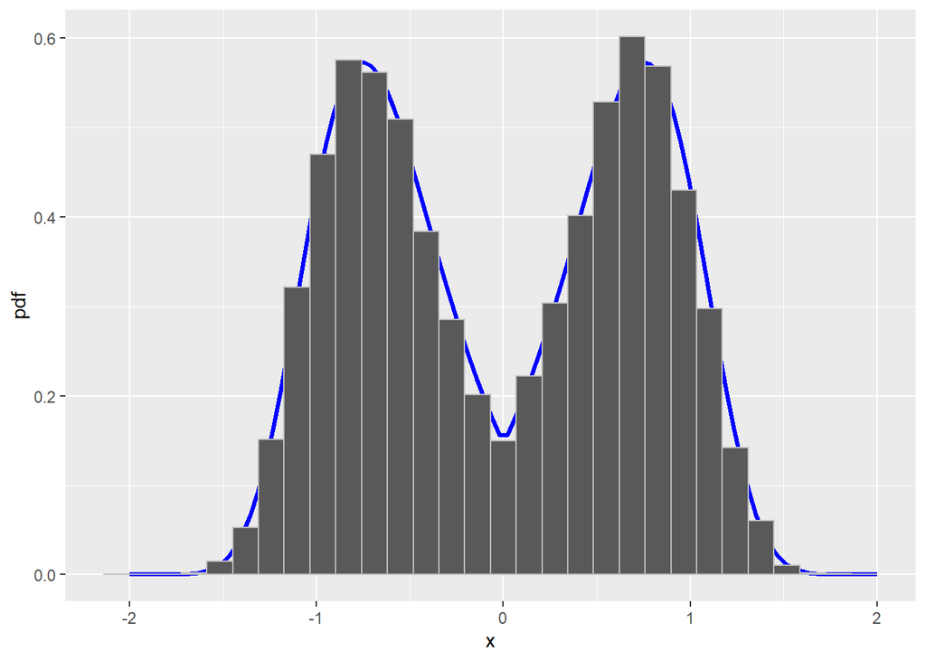

```r
library(ggplot2)
alphafun = function(x, y) {
  exp(-y^4 + x^4)*(1+abs(y))^3*(1+abs(x))^{-3}
}
mh_mcmc = function(alphafn, burnin, N, thin) {
  x = numeric(burnin + N*thin)
  x[1] = rnorm(1)
  for (i in 2:(burnin + N*thin)) {
    propy = rnorm(1, x[i - 1], 1)
    alpha = min(1, alphafn(x[i-1], propy))
    x[i] = ifelse(rbinom(1, 1, alpha), propy, x[i-1])
  }
  return(x[burnin + (1:N)*thin])
}
sample = mh_mcmc(alphafun, 5000, 10000, 10)
f_true = function(x) {
  exp(-x^4)*(1+abs(x))^3
}
integral = integrate(f_true, 0, Inf)
c = 2 * integral$value
f_true = function(x) {
  exp(-x^4)*(1+abs(x))^3 / c
}
f_true_plot.dat = data.frame(x = seq(-2, 2, length = 100),
                             y = f_true(seq(-2, 2, length = 100)))
ggplot(f_true_plot.dat, aes(x, y)) +
  geom_line(color = "blue", size = 1.2) + ylab("pdf") +
  geom_histogram(data = data.frame(x = sample), aes(x = x, y = ..density..),
                 color = "gray")
```